# 5510-Projecxt

AryanSultan_T13_Wed_kable

5/17/2021

## 0.1 How long did it take on average for the CFA brigade to respond to incidents in their own areas for hazard class 2 in Q4 2018/19 and Q4 2019/20? Also, this will be analyzed against the standard time (given in the data for each of the hazard classes). (CFA Emergency Response Time)

### 0.1.1 Introduction

There are three critical components of CFA delivery services: Response time: This is measured from when the brigade is alerted to an event to when the brigade arrives at the scene.

Brigade area: Each brigade has a defined brigade area, which specifies the operational footprint of the brigade.

Hazard classes: Hazard class defines the type of risk for a given area. Each brigade area may contain multiple hazard classes. However, each hazard class has a predefined service delivery standards.

In the data we have two variables that record the amount of time it CFA brigade to respond to incidents in specified areas:

- The time in which 90% of emergency incidents were responded to by any brigade; and,
- The time in which 90% of emergency incidents were responded to by the brigade within their own Brigade Area

The variable of interest for us is : The time in which 90% of emergency incidents were responded to by the brigade within their own Brigade Area. The reason is because we want to find out the mean time in which CFA brigade responded to incidents in their own brigade areas.

For this purpose, I did bit of data wrangling:

- renamed variables such that now we have a `TimeReponse` variable, and `TimeReponse_within`variable.
- mutate Number of incidents into a numeric vector.
- Changed the character variables to time using the contributed library chron.

For this specific question, we are going to analyze the data for *Hazard Class 2* that covers significant urban areas and is primarily residential including commercial centres, clusters of industrial and/or high density community services e.g. schools, correctional facilities, hospitals.

CFA has service delivery standards, which specify a response time target for a brigade to attend an emergency incident. The service delivery standard (response time) for Hazard Class 2 is **8 minutes**. Hence the analysis will be carried against this standard response time.

```r
data_20 <- read.csv("data/dat_q4_2020.csv") %>%
  rename(CFA_district = CFA.District)%>%
  rename(CFA_Brigade_Area = CFA.Brigade.Area)%>%
  rename(Number_of_incidents = `Number.of.emergency.incidents.within.the.Brigade.Area.for.the.reporting.period.for.Hazard.Class.2`)%>%
  rename(TimeResponse = `The.time.in.which.90..of.emergency.incidents.were.responded.to.by.any.brigade`)%>%
  rename(TimeResponse_within = `The.time.in.which.90..of.emergency.incidents.were.responded.to.by.the.brigade.within.their.own.Brigade.Area`)%>%
  mutate(`TimeResponse_within`= paste0("00:",`TimeResponse_within`))%>%
  mutate(TimeResponse = paste0("00:",TimeResponse))%>%
  mutate(Number_of_incidents = as.numeric(Number_of_incidents))

data_20
```

```
##     X CFA_district CFA_Brigade_Area Number_of_incidents TimeResponse
## 1   1            2          Bendigo                  71     00:06:51
## 2   2            2        Eaglehawk                  17     00:09:45
## 3   3            2    Golden Square                  21     00:07:45
## 4   4            2    Kangaroo Flat                  27     00:09:39
## 5   5            4         Portland                  12     00:06:30
## 6   6            5      Warrnambool                  86     00:07:28
## 7   7            7          Belmont                  61     00:06:49
## 8   8            7            Corio                 105     00:07:51
## 9   9            7     Geelong City                 117     00:06:40
## 10 10            7     Geelong West                  16     00:08:21
## 11 11            7             Lara                  36     00:11:00
## 12 12            7      Ocean Grove                  13     00:05:56
## 13 13            7          Torquay                  36     00:11:58
## 14 14            8          Berwick                  16     00:05:49
```

[output cut: 43 more lines]

```r
library(chron)

data_20$TimeResponse_within <- chron(times= data_20$TimeResponse_within)


data_20
```

```
##     X CFA_district CFA_Brigade_Area Number_of_incidents TimeResponse
## 1   1            2          Bendigo                  71     00:06:51
## 2   2            2        Eaglehawk                  17     00:09:45
## 3   3            2    Golden Square                  21     00:07:45
## 4   4            2    Kangaroo Flat                  27     00:09:39
## 5   5            4         Portland                  12     00:06:30
## 6   6            5      Warrnambool                  86     00:07:28
## 7   7            7          Belmont                  61     00:06:49
## 8   8            7            Corio                 105     00:07:51
## 9   9            7     Geelong City                 117     00:06:40
## 10 10            7     Geelong West                  16     00:08:21
## 11 11            7             Lara                  36     00:11:00
## 12 12            7      Ocean Grove                  13     00:05:56
## 13 13            7          Torquay                  36     00:11:58
## 14 14            8          Berwick                  16     00:05:49
```

[output cut: 43 more lines]

```r
data_20$TimeResponse <- chron(times=data_20$TimeResponse)

data_20
```

```
##     X CFA_district CFA_Brigade_Area Number_of_incidents TimeResponse
## 1   1            2          Bendigo                  71     00:06:51
## 2   2            2        Eaglehawk                  17     00:09:45
## 3   3            2    Golden Square                  21     00:07:45
## 4   4            2    Kangaroo Flat                  27     00:09:39
## 5   5            4         Portland                  12     00:06:30
## 6   6            5      Warrnambool                  86     00:07:28
## 7   7            7          Belmont                  61     00:06:49
## 8   8            7            Corio                 105     00:07:51
## 9   9            7     Geelong City                 117     00:06:40
## 10 10            7     Geelong West                  16     00:08:21
## 11 11            7             Lara                  36     00:11:00
## 12 12            7      Ocean Grove                  13     00:05:56
## 13 13            7          Torquay                  36     00:11:58
## 14 14            8          Berwick                  16     00:05:49
```

[output cut: 43 more lines]

### 0.1.2 Context

The most recent data from April to June 2020 showed CFA brigades responded to 9,120 incidents, of which 4,893 required an emergency response.

In 87 per cent of incidents that required emergency response, the community received a fire service within the standard response time, which was broadly consistent with previous quarters.[CFA News](https://news.cfa.vic.gov.au/-/cfa-release-latest-response-data)

Let’s visualize the data first.

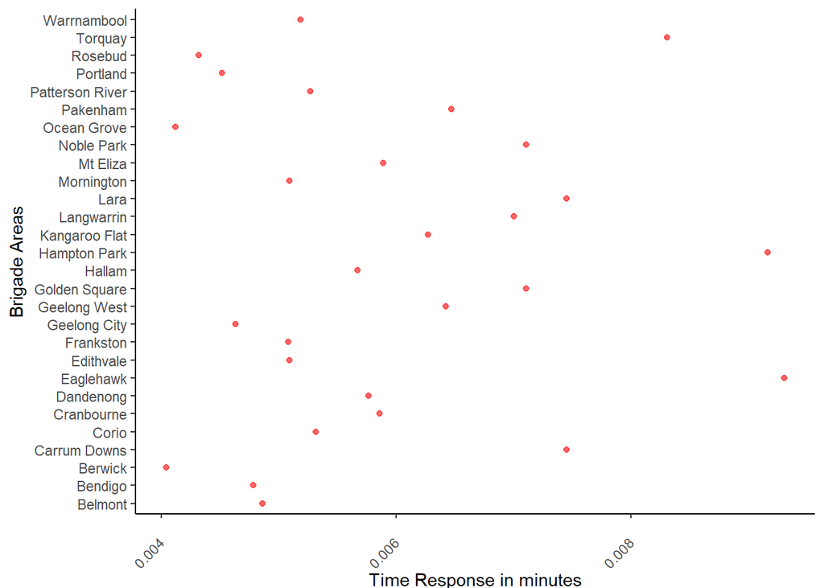

```r
ggplot(data_20) +
  geom_point(data = data_20,
aes(x = TimeResponse_within,
y = CFA_Brigade_Area),
color = "red",
alpha = 0.6)+
  theme_classic()+
  theme(axis.text.x = element_text(angle = 45, vjust = 0.5, hjust=1), axis.title.x = element_text(vjust=-1.8))+
  labs(x = "Time Response in minutes",
y = "Brigade Areas")
```

```r
data_20 %>%
  select(TimeResponse_within)%>%
  summary(data_20$TimeResponse_within)%>%
  kable() %>%
kable_styling(bootstrap_options = c("striped","hover"))
```

|  | TimeResponse_within |
| --- | --- |
|  | Min. :00:05:49 |
|  | 1st Qu.:00:07:14 |
|  | Median :00:08:14 |
|  | Mean :00:08:37 |
|  | 3rd Qu.:00:10:07 |
|  | Max. :00:13:24 |

The mean time that it took CFA brigades to respond to incidents in their own CFA brigade areas is 0.0059838. This is very close to the target response time for brigades, which is eight minutes.

```r
data20_avgRT <- function(TimeResponse_within){

  m = sum(TimeResponse_within)/length(TimeResponse_within)
  return(m)
}
data20_avgRT(data_20$TimeResponse_within)
```

```
## [1] 00:08:37
```

For the year 2018/19, we have used the data belonging to the year 2018/19, which was acquired from the [CFA official site](https://discover.data.vic.gov.au/organization/country-fire-authority).

The most recent data set from July to September 2019 showed CFA brigades responding to 9,830 incidents, of which 5,013 required an emergency response.

In 87 per cent of emergencies, the community received a fire service within the standard response time, which was broadly consistent with previous quarters.[CFA News](https://news.cfa.vic.gov.au/-/cfa-releases-latest-response-data)

For this part of the question, I repeated the same data cleaning steps as mentioned above.

```r
data_19 <- read.csv("data/dat_q4_2018_19.csv")%>%
  rename(CFA_district = CFA.District)%>%
  rename(CFA_Brigade_Area = CFA.Brigade.Area)%>%
  rename(Number_of_incidents = `Number.of.emergency.incidents.within.the.Brigade.Area.for.the.reporting.period.for.Hazard.Class.2`)%>%
  rename(TimeResponse = `The.time.in.which.90..of.emergency.incidents.were.responded.to.by.any.brigade`)%>%
  rename(TimeResponse_within = `The.time.in.which.90..of.emergency.incidents.were.responded.to.by.the.brigade.within.their.own.Brigade.Area`)%>%
  filter(TimeResponse_within != "NULL")%>%
  mutate(`TimeResponse_within`= paste0("00:",`TimeResponse_within`))%>%
  mutate(TimeResponse = paste0("00:",TimeResponse))%>%
  mutate(Number_of_incidents = as.numeric(Number_of_incidents))


data_19
```

```
##     X CFA_district CFA_Brigade_Area Number_of_incidents TimeResponse
## 1   1            2          Bendigo                  58     00:07:32
## 2   2            2      Castlemaine                  10     00:09:36
## 3   3            2        Eaglehawk                  16     00:09:23
## 4   4            2    Kangaroo Flat                  12     00:07:48
## 5   5            4         Portland                  19     00:07:00
## 6   6            5      Warrnambool                  44     00:07:13
## 7   7            6            Colac                  10     00:07:46
## 8   8            7          Belmont                  56     00:07:07
## 9   9            7            Corio                 102     00:07:31
## 10 10            7     Geelong City                 122     00:06:47
## 11 11            7             Lara                  26     00:10:28
## 12 12            7      Ocean Grove                  10     00:05:28
## 13 13            7          Torquay                  15     00:11:55
## 14 14            8          Berwick                  25     00:06:46
```

[output cut: 109 more lines]

```r
library(chron)

data_19$TimeResponse_within <- chron(times= data_19$TimeResponse_within)



data_19
```

```
##     X CFA_district CFA_Brigade_Area Number_of_incidents TimeResponse
## 1   1            2          Bendigo                  58     00:07:32
## 2   2            2      Castlemaine                  10     00:09:36
## 3   3            2        Eaglehawk                  16     00:09:23
## 4   4            2    Kangaroo Flat                  12     00:07:48
## 5   5            4         Portland                  19     00:07:00
## 6   6            5      Warrnambool                  44     00:07:13
## 7   7            6            Colac                  10     00:07:46
## 8   8            7          Belmont                  56     00:07:07
## 9   9            7            Corio                 102     00:07:31
## 10 10            7     Geelong City                 122     00:06:47
## 11 11            7             Lara                  26     00:10:28
## 12 12            7      Ocean Grove                  10     00:05:28
## 13 13            7          Torquay                  15     00:11:55
## 14 14            8          Berwick                  25     00:06:46
```

[output cut: 109 more lines]

```r
data_19$TimeResponse <- chron(times=data_19$TimeResponse)

data_19
```

```
##     X CFA_district CFA_Brigade_Area Number_of_incidents TimeResponse
## 1   1            2          Bendigo                  58     00:07:32
## 2   2            2      Castlemaine                  10     00:09:36
## 3   3            2        Eaglehawk                  16     00:09:23
## 4   4            2    Kangaroo Flat                  12     00:07:48
## 5   5            4         Portland                  19     00:07:00
## 6   6            5      Warrnambool                  44     00:07:13
## 7   7            6            Colac                  10     00:07:46
## 8   8            7          Belmont                  56     00:07:07
## 9   9            7            Corio                 102     00:07:31
## 10 10            7     Geelong City                 122     00:06:47
## 11 11            7             Lara                  26     00:10:28
## 12 12            7      Ocean Grove                  10     00:05:28
## 13 13            7          Torquay                  15     00:11:55
## 14 14            8          Berwick                  25     00:06:46
```

[output cut: 109 more lines]

Let’s visualize the data for the year 2018/19.

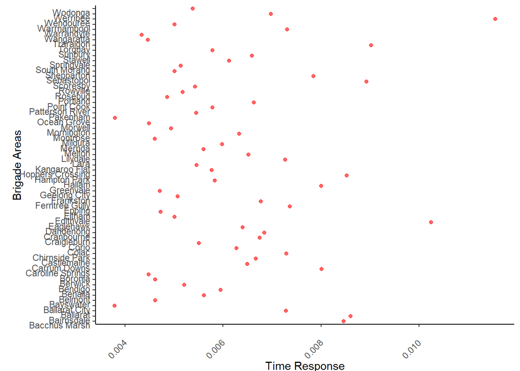

```r
ggplot(data_19) +
  geom_point(data = data_19,
aes(x = TimeResponse_within,
y = CFA_Brigade_Area),
color = "red",
alpha = 0.6)+
  theme_classic()+
  theme(axis.text.x = element_text(angle = 45, vjust = 0.5, hjust=1), axis.title.x = element_text(vjust=-1.8))+
  theme(axis.text.y =  element_text(angle = , vjust = 1, hjust=1), axis.title.y =  element_text(vjust=-1.8))+
labs(x = "Time Response",
y = "Brigade Areas")
```

```r
data_19%>%
  select(TimeResponse_within)%>%
  summary(data_19$TimeResponse_within)%>%
  kable() %>%
kable_styling(bootstrap_options = c("striped","hover"))
```

|  | TimeResponse_within |
| --- | --- |
|  | Min. :00:05:27 |
|  | 1st Qu.:00:07:13 |
|  | Median :00:08:24 |
|  | Mean :00:08:56 |
|  | 3rd Qu.:00:10:03 |
|  | Max. :00:16:38 |

Using the summary function, we can see that the mean time taken by the CFA brigades to respond to the incidents in their own areas was 0.0062073. This is agian very close to the target standard which was eight minutes.

```r
data19_avgRT <- function(TimeResponse_within){

  m = sum(TimeResponse_within, na.rm = TRUE)/length(TimeResponse_within)
  return(m)
}
data19_avgRT(data_19$TimeResponse_within)
```

```
## [1] 00:08:56
```

## 0.2 Which of the CFA brigade areas have had the highest number of incidents across Hazard classes for the reported period (2019/20) (four quarters). (CFA Emergency Response Time)

### 0.2.1 Introduction

In this question, we have one variable that records the number of incidents across all hazard classes for all the specified districts. There are three predefined hazard classes: 2, 3 and 4.

- Hazard class 2 (Medium Urban): This includes significant urban areas which are primarily residential including commercial centres, clusters of industrial and/or high density community services e.g. schools, correctional facilities, hospitals. (8 minutes SDS).
- Hazard Class 3 (Low Urban): This includes all urban areas that are not included in Hazard Class 2 and includes predominantly residential occupancies and small industries. (10 minutes SDS).
- Hazard Class 4 (Rural): This includes primarily the natural surroundings in terms of bush and grassland, but also involves isolated dwellings and structures within those areas.

The variable of interest for us is : Number_Incidents_total.

For this purpose, I did bit of data wrangling:

- renamed variables such that now we have a `CFA_Brigade_Area` variable, and `Number_Incidents_total`variable in each data set. (I had four datasets for Quarters 1, 2, 3,and 4)
- mutate Number of incidents into a numeric vector.
- Join data using bind_rows

### 0.2.2 Context

In this question we are concerned with district that has had the highest number of incidents across all hazard classes in the year 2019/20.

Let’s first visualize data from each data set for the quarters 1, 2, 3 and 4 for the year 2019/20.

```r
dat_Q1_2020 <- read_csv("data/dat_Q1_2020.csv") %>%
  rename(Number_Incidents_total =`Number of incidents within the Brigade Area for the reporting period across all Hazard Classes`)%>%
  rename(CFA_Brigade_Area = `CFA Brigade Area`)

dat_Q1_2020
```

```
## # A tibble: 68 x 4
##       X1 `CFA District` CFA_Brigade_Area Number_Incidents_total
##    <dbl> <chr>          <chr>                             <dbl>
##  1     1 02             Bendigo                             198
##  2     2 02             Golden Square                        24
##  3     3 02             Kangaroo Flat                        37
##  4     4 04             Portland                             43
##  5     5 05             Hamilton                             24
##  6     6 05             Warrnambool                         116
##  7     7 07             Belmont                             114
##  8     8 07             Corio                               247
##  9     9 07             Geelong City                        280
## 10    10 07             Geelong West                         33
## # ... with 58 more rows
```

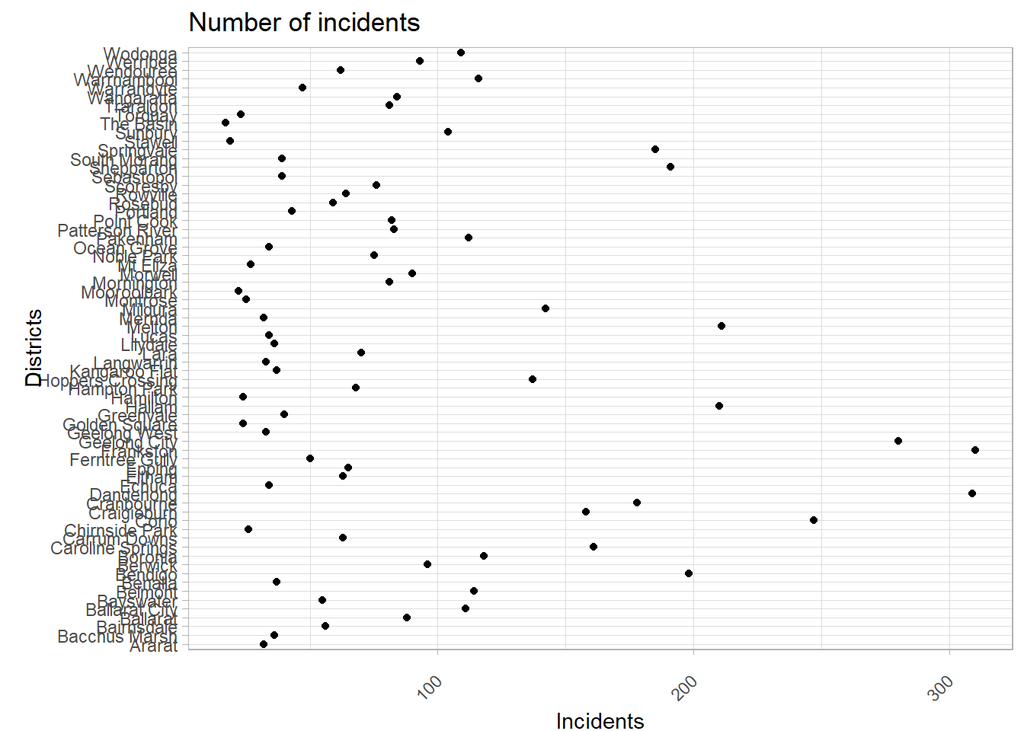

```r
ggplot(dat_Q1_2020, aes( x = Number_Incidents_total,
                         y = CFA_Brigade_Area)) +
geom_point() +
  theme_light() +
  theme(axis.text.x = element_text(angle = 45, vjust = 0.5, hjust=1), axis.title.x = element_text(vjust=-1.8))+
  theme(axis.text.y =  element_text(angle = , vjust = 0.5, hjust=1), axis.title.y =  element_text(vjust=-1.8))+

  xlab("Incidents") +
 ylab("Districts") +
  ggtitle("Number of incidents")
```

The above plot shows us the number of incidents for the first quarter 2019/20. On the x-axis we have number of incidents and the y-axis we can see the names of districts.

```r
dat_Q2_2020 <- read_csv("data/dat_Q2_2020.csv")%>%
  rename(Number_Incidents_total = `Number of incidents within the Brigade Area for the reporting period across all Hazard Classes`)%>%
  rename(CFA_Brigade_Area = `CFA Brigade Area`)

dat_Q2_2020
```

```
## # A tibble: 77 x 4
##       X1 `CFA District` CFA_Brigade_Area Number_Incidents_total
##    <dbl> <chr>          <chr>                             <dbl>
##  1     1 02             Bendigo                             225
##  2     2 02             Eaglehawk                            47
##  3     3 02             Golden Square                        24
##  4     4 02             Kangaroo Flat                        47
##  5     5 04             Portland                             35
##  6     6 05             Hamilton                             31
##  7     7 05             Warrnambool                         124
##  8     8 06             Colac                                43
##  9     9 07             Belmont                             112
## 10    10 07             Corio                               220
## # ... with 67 more rows
```

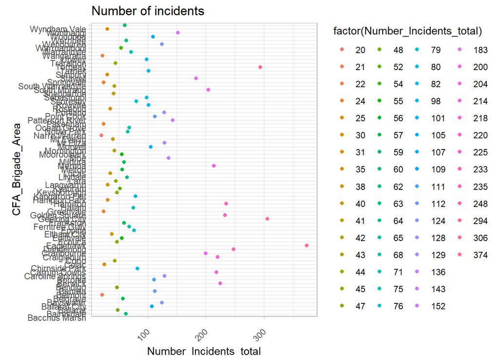

```r
 ggplot(dat_Q2_2020, aes(x = Number_Incidents_total ,
                            y = CFA_Brigade_Area,
                            colour = factor(Number_Incidents_total)))+

  geom_point() +
  theme_light() +
  theme(axis.text.x = element_text(angle = 45, vjust = 0.5, hjust=1), axis.title.x = element_text(vjust=-1.8))+
  theme(axis.text.y =  element_text(angle = , vjust = 1, hjust=1), axis.title.y =  element_text(vjust=-1.8))+
  ggtitle("Number of incidents")
```

Similiar to the plot above, this plot shows us the number of incidents for the second quarter 2019/20. On the x-axis we have number of incidents and the y-axis we can see the names of districts.

```r
dat_Q3_2020 <- read_csv("data/dat_Q3_2020.csv") %>%
  rename(Number_Incidents_total = `Number of incidents within the Brigade Area for the reporting period across all Hazard Classes`)%>%
  rename(CFA_Brigade_Area = `CFA Brigade Area`)


dat_Q3_2020
```

```
## # A tibble: 70 x 4
##       X1 `CFA District` CFA_Brigade_Area Number_Incidents_total
##    <dbl> <chr>          <chr>                             <dbl>
##  1     1 02             Bendigo                             205
##  2     2 02             Eaglehawk                            32
##  3     3 02             Golden Square                        30
##  4     4 02             Kangaroo Flat                        25
##  5     5 04             Portland                             38
##  6     6 05             Hamilton                             32
##  7     7 05             Warrnambool                         133
##  8     8 07             Belmont                             130
##  9     9 07             Corio                               258
## 10    10 07             Geelong City                        264
## # ... with 60 more rows
```

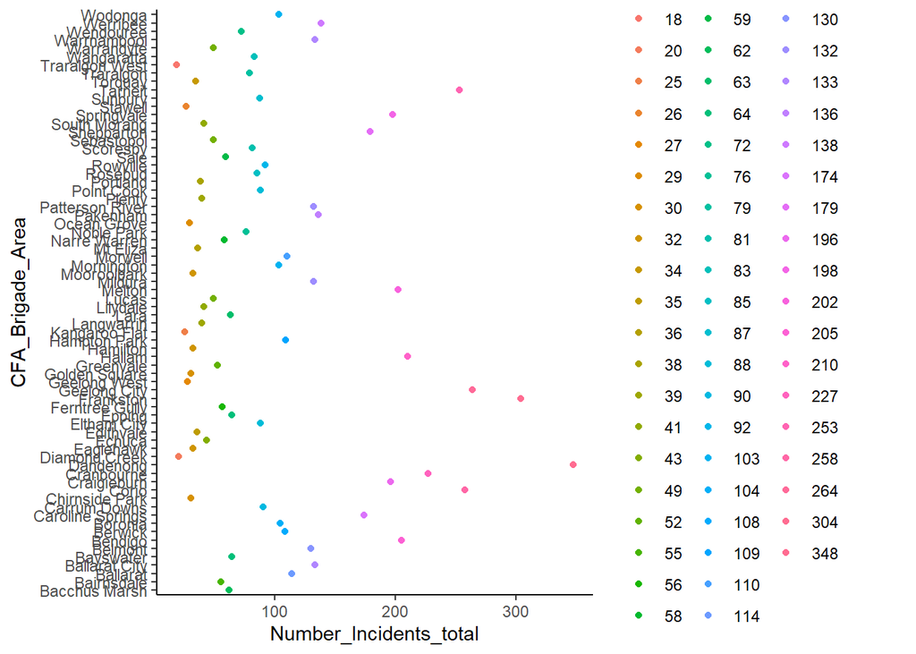

```r
 ggplot(dat_Q3_2020) +
geom_point(aes(x = Number_Incidents_total,
y = CFA_Brigade_Area,
colour = factor(Number_Incidents_total)))  +
  theme_classic()
```

The above plot shows us the number of incidents for the third quarter 2019/20. On the x-axis we have number of incidents and the y-axis we can see the names of districts.

```r
dat_Q4_2020 <- read_csv("data/dat_2020Q4.csv")%>%
  select(`CFA District`, `CFA Brigade Area`, `Number of incidents within the Brigade Area for the reporting period across all Hazard Classes`)%>%
  rename(Number_Incidents_total = `Number of incidents within the Brigade Area for the reporting period across all Hazard Classes`)%>%
    rename(CFA_Brigade_Area = `CFA Brigade Area`)

dat_Q4_2020
```

```
## # A tibble: 28 x 3
##    `CFA District` CFA_Brigade_Area Number_Incidents_total
##    <chr>          <chr>                             <dbl>
##  1 02             Bendigo                             155
##  2 02             Eaglehawk                            38
##  3 02             Golden Square                        32
##  4 02             Kangaroo Flat                        38
##  5 04             Portland                             30
##  6 05             Warrnambool                         127
##  7 07             Belmont                             103
##  8 07             Corio                               207
##  9 07             Geelong City                        188
## 10 07             Geelong West                         25
## # ... with 18 more rows
```

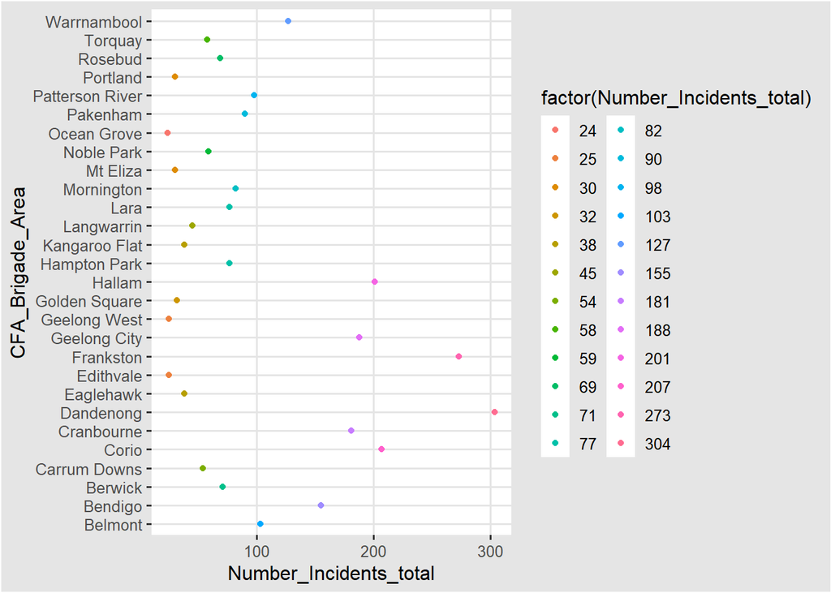

```r
ggplot(dat_Q4_2020) +
geom_point(aes(x = Number_Incidents_total,
y = CFA_Brigade_Area,
colour = factor(Number_Incidents_total))) +
  theme_igray()
```

The above plot shows us the number of incidents for the fourth quarter 2019/20. On the x-axis we have number of incidents and the y-axis we can see the names of districts.

```r
binding_data <- bind_rows(dat_Q1_2020,dat_Q2_2020,dat_Q3_2020,dat_Q4_2020)

binding_data
```

```
## # A tibble: 243 x 4
##       X1 `CFA District` CFA_Brigade_Area Number_Incidents_total
##    <dbl> <chr>          <chr>                             <dbl>
##  1     1 02             Bendigo                             198
##  2     2 02             Golden Square                        24
##  3     3 02             Kangaroo Flat                        37
##  4     4 04             Portland                             43
##  5     5 05             Hamilton                             24
##  6     6 05             Warrnambool                         116
##  7     7 07             Belmont                             114
##  8     8 07             Corio                               247
##  9     9 07             Geelong City                        280
## 10    10 07             Geelong West                         33
## # ... with 233 more rows
```

### 0.2.3 Analysis

Using the summary function we can see the maximum number of incidents across all hazard classes for specified districts for the given time frame. Data used here is the merged data of the four data sets, using bind_rows function.

```r
DataQ1_4 <-  read_csv("data/Question_3_dat_2.csv")%>%
  rename(Num_incdents1=`Number of incidents within the Brigade Area for the reporting period across all Hazard Classes Q1`)%>%
  rename(Num_incdents2=`Number of incidents within the Brigade Area for the reporting period across all Hazard Classes Q2`)%>%
  rename(Num_incdents3=`Number of incidents within the Brigade Area for the reporting period across all Hazard Classes Q3`)%>%
  rename(Num_incdents4=`Number of incidents within the Brigade Area for the reporting period across all Hazard Classes Q4`)
```

```r
DataQ1 <- DataQ1_4 %>%
  select(Num_incdents1,
         Num_incdents2,
         Num_incdents3,
         Num_incdents4)%>%
  summary()%>%
  kable(caption = "Summary of the incidents.") %>%
  kable_styling(bootstrap_options = c("striped", "hover"))

DataQ1
```

Table 1: Summary of the incidents.

|  | Num_incdents1 | Num_incdents2 | Num_incdents3 | Num_incdents4 |
| --- | --- | --- | --- | --- |
|  | Min. : 23.0 | Min. : 24.0 | Min. : 25.0 | Min. : 24.0 |
|  | 1st Qu.: 63.0 | 1st Qu.: 52.0 | 1st Qu.: 76.0 | 1st Qu.: 54.0 |
|  | Median : 83.0 | Median :101.0 | Median :108.0 | Median : 77.0 |
|  | Mean :125.5 | Mean :126.8 | Mean :134.2 | Mean :110.1 |
|  | 3rd Qu.:185.0 | 3rd Qu.:183.0 | 3rd Qu.:198.0 | 3rd Qu.:181.0 |
|  | Max. :310.0 | Max. :374.0 | Max. :348.0 | Max. :304.0 |

In the above table, we can see the summary for number of incidents in each quarter; we see that the highest number of incidents was recorded as 374 in the second quarter.

The data used here is the merged data that contains information on all four quarters. For the next steps, we will use the binding_data from above.

```r
 Highest_NumberIncidents <- binding_data%>%
  select(Number_Incidents_total)%>%
summary()%>%
  kable(caption = "This is the summary of number of incidents across all hazard classes") %>%
  kable_styling(bootstrap_options = c("striped", "hover"))

Highest_NumberIncidents
```

Table 2: This is the summary of number of incidents across all hazard classes

|  | Number_Incidents_total |
| --- | --- |
|  | Min. : 17.00 |
|  | 1st Qu.: 39.50 |
|  | Median : 71.00 |
|  | Mean : 95.96 |
|  | 3rd Qu.:125.50 |
|  | Max. :374.00 |

We can see that highest number of incidents are 374, so now using the filter function. let’s see which district has 374 incidents.

```r
binding_data%>%
  select(-X1,
         -`CFA District`)%>%
  filter(Number_Incidents_total == "374" )%>%
  kable(caption = "Dandenong district has the highest number of incidents across all hazard classes in all of the four quarters.") %>%
  kable_styling(bootstrap_options = c("striped", "hover"))
```

| CFA_Brigade_Area | Number_Incidents_total |
| --- | --- |
| Dandenong | 374 |

From the table we can see that Dandenong has had the highest number of incidents.

## 0.4 Fire Detections and Land Type in Bushfire Season

```r
fire_total_detects %>%
  select(Years, n) %>%
  arrange(desc(n)) %>%
  rename("Total Counts" = n) %>%
  kable(caption = "Total detections by year") %>%
 kable_styling(c("hover",
                  "condensed",
                  position = "center",
                  fixed_thead = TRUE),
                latex_options = "HOLD_position", full_width = FALSE)
```

Table 4: Total detections by year

| Years | Total Counts |
| --- | --- |
| 2006/2007 | 3327484 |
| 2002/2003 | 2974094 |
| 2013/2014 | 1016454 |
| 2008/2009 | 784110 |
| 2012/2013 | 736251 |
| 2010/2011 | 685265 |
| 2005/2006 | 557492 |
| 2018/2019 | 545723 |
| 2014/2015 | 523801 |
| 2009/2010 | 487338 |
| 2017/2018 | 469092 |
| 2004/2005 | 461358 |
| 2003/2004 | 446818 |
| 2011/2012 | 416408 |
| 2007/2008 | 381934 |
| 2016/2017 | 377902 |
| 2015/2016 | 315854 |
| 2019/2020 | 103627 |

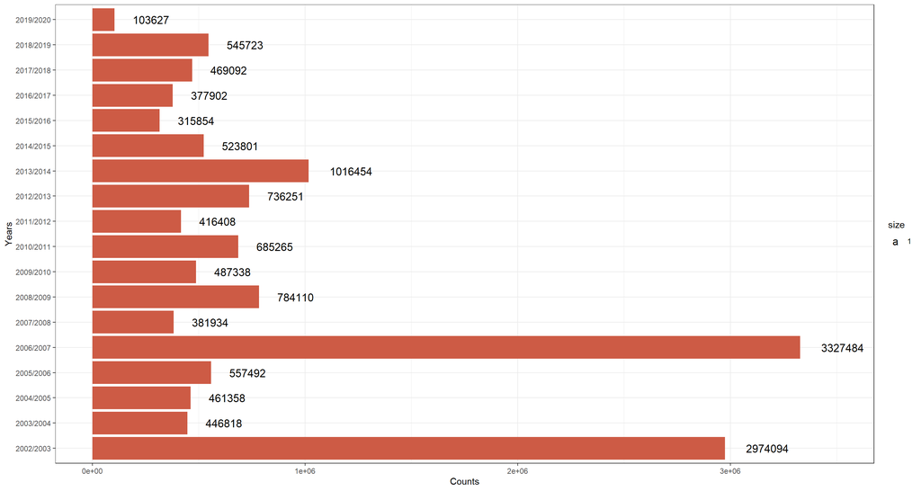

Figure 1: Number of Observations by Year

```r
 ggplot(fire_total_detects,
                          aes(x = Years,
                              y = n)) +
  geom_col(fill= 'coral3') +
  coord_flip()+
  labs( y = "Counts") +
  geom_text(aes(label = n, size = 1, hjust= -0.5))+
  theme(legend.position = "none")+
  scale_y_continuous(limits = c(0,3500000))+
  theme_bw()
```

### 0.4.1 Percentage of Affected Land by State

Taking in detail the number of the observations by state in the season 2019/2020, we can see that the states with major affectation of the forested land were Australian Capital Territory, Victoria and New south Wales with 92.78%, 92.02% and 90.15% respectively. See Figure 2. The territory with the least affectation was Northern Territory (0%), followed by South Australia with 43.68%.

```r
perc_affected_state <- perc_affected_state  %>%
  select(Jurisdiction,
         `Proportion of fire area that is forested (perc)`) %>%
  mutate("Proportion of fire" = 100-`Proportion of fire area that is forested (perc)`) %>%
  pivot_longer(names_to = "Burnt Area",
               values_to = "Percentage",
               cols = -Jurisdiction)
```

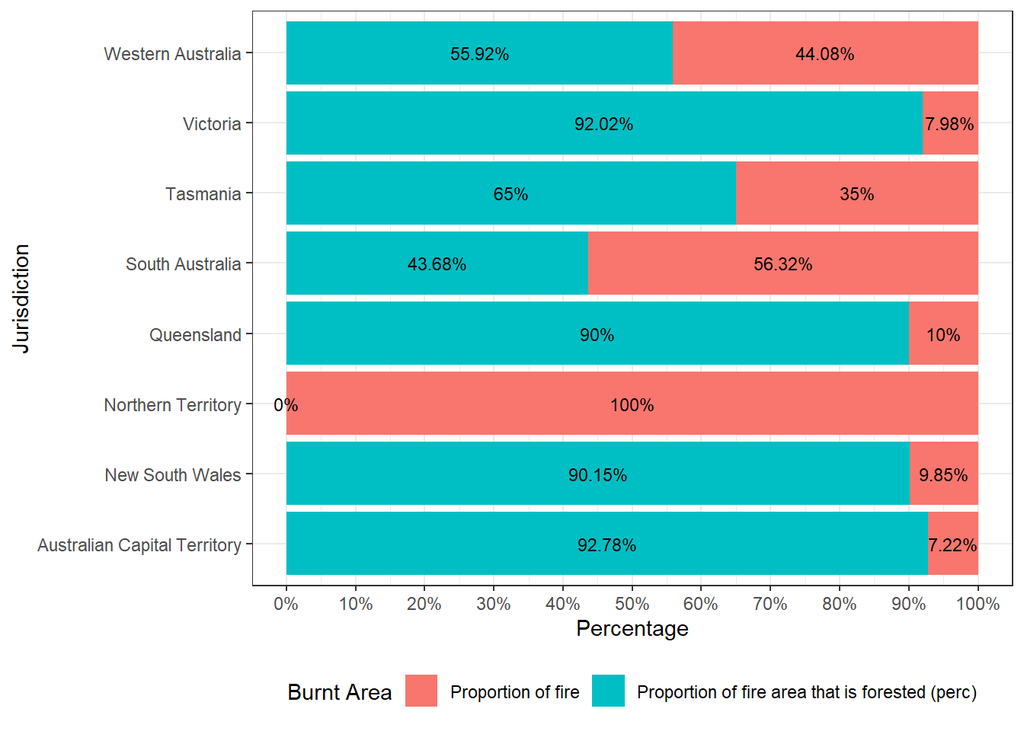

Figure 2: Affectation by State

```r
ggplot(data = perc_affected_state, aes(x = Jurisdiction,
                           y = Percentage,
                           fill= `Burnt Area`)) +
    geom_bar(position="stack",
             stat="identity")+
    geom_text(aes(label = paste0(round(Percentage,2),"%")),
              position = position_stack(vjust = 0.5),
              size = 3)+
    scale_y_continuous(labels = function(x) paste0(x, "%"),
                       breaks = seq(0, 100, 10))+
    coord_flip()+
    theme_bw()+
    theme(legend.position = "bottom")
```

### 0.4.2 Percentage of Forested Land Affected in Victoria by Type

According to the classification of the land in Victoria, Multiple-use Public Forest got affected by 29%, whereas the Nature Conservation Reserve had 15% of burnt land. similarly the Unresolved tenure land lost 13% of it’s extent by the fires. In the case of private land, around 6% was consumed by fires. See Figure 3.

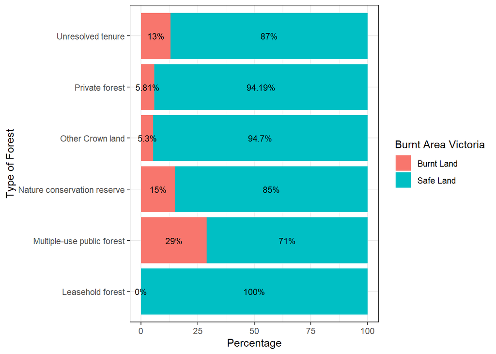

Figure 3: Land Type affected in Victoria

```r
ft4perc <- ft4perc  %>%
  select(...1,Vic.) %>%
  rename("Type of Forest" = ...1, "Burnt Land" = Vic.) %>%
  filter(`Type of Forest` %in%
           c("Leasehold forest",
             "Multiple-use public forest",
             "Nature conservation reserve",
             "Other Crown land",
             "Private forest",
             "Unresolved tenure")) %>%
  mutate("Safe Land" = 100-`Burnt Land`) %>%
  pivot_longer(names_to = "Burnt Area Victoria", values_to = "Percentage", cols = -`Type of Forest`)

  ggplot(data = ft4perc, aes(x = `Type of Forest`,
                           y = Percentage, fill= `Burnt Area Victoria`)) +
    geom_bar(position= position_stack(reverse = T), stat="identity")+
    coord_flip()+
    theme(legend.position = "bottom")+
    theme_bw() +
    geom_text(aes(label = paste0(round(Percentage,2),"%")), position = position_stack(vjust = 0.5, reverse = T), size = 3)
```

## 0.5 Melbourne Air Quality Index

The bushfires season had a huge negative impact in the air quality in Victoria, as an example we took data from the Environment Protection Authority in Australia which recorder the PM2.5 (Fine Particulate Matter 2.5) which is an air pollutant concern for the community’s health, the higher the rate the worse impact for individuals. In the figure 4 below can be seen the levels for the previous four years, with clearly a huge peak in January 2020.

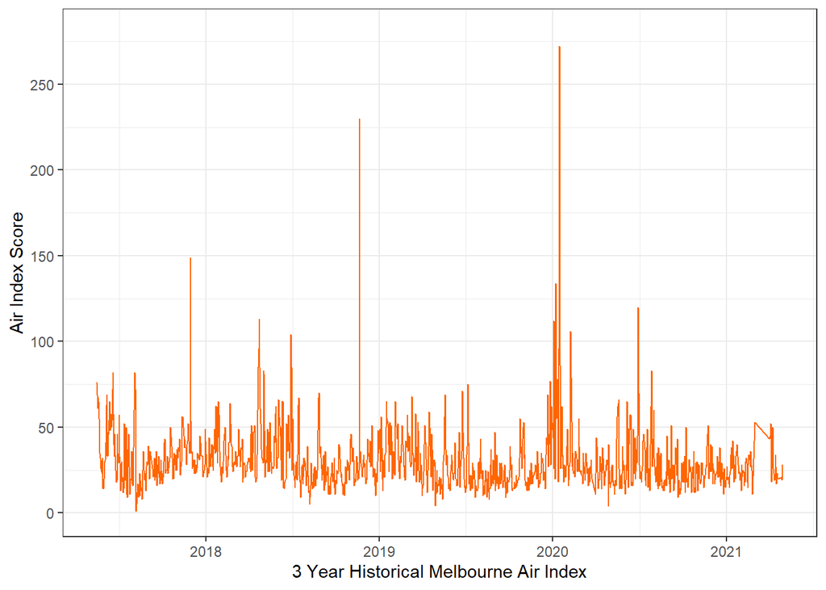

Figure 4: Melbourne Air Quality

```r
melb_air2 <- melb_air %>%  select(date,pm25) %>%
  mutate(date = as.Date(date, format = "%d/%m/%Y"))

melb_air2 %>%
  ggplot()+
  geom_line(aes(x = date,
                y = pm25),
            colour = "#FF6600")+
  theme_bw()+
  labs(x = "3 Year Historical Melbourne Air Index",
       y = "Air Index Score")+
  scale_y_continuous(limits = c(0,280),
                     breaks = seq(0,280,50))
```

The figure below shows the classification of the air quality index, this source will give a clearer idea of the readings of the bushfire season and for previous levels.

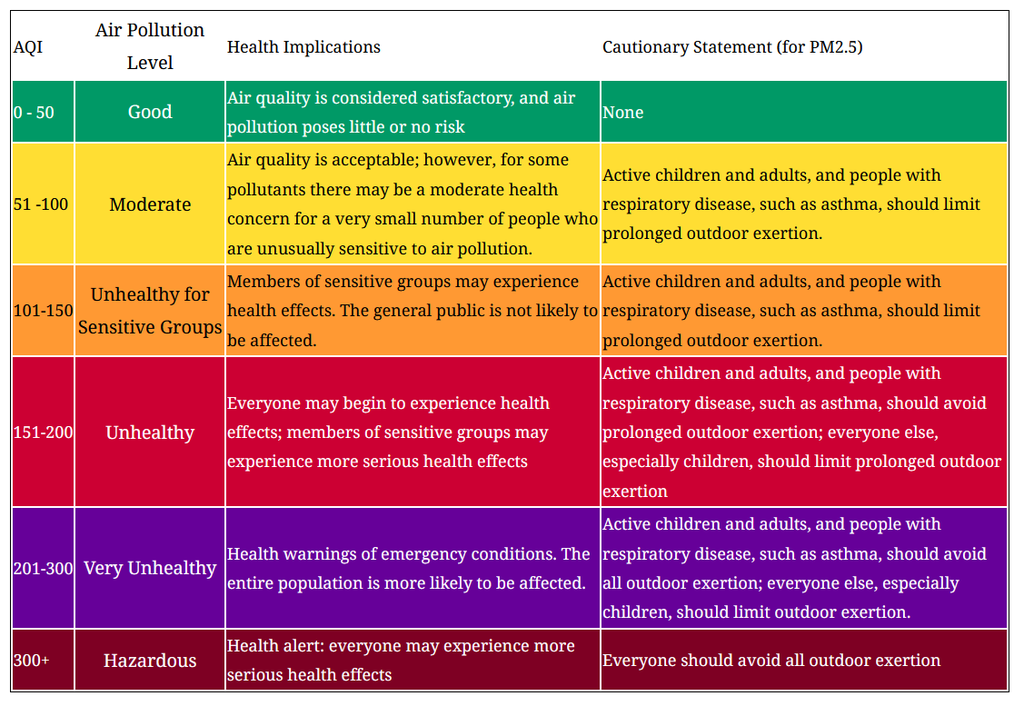

Figure 5: Air Quality Levels

```r
knitr::include_graphics(here::here('images/polution_table.png'))
```

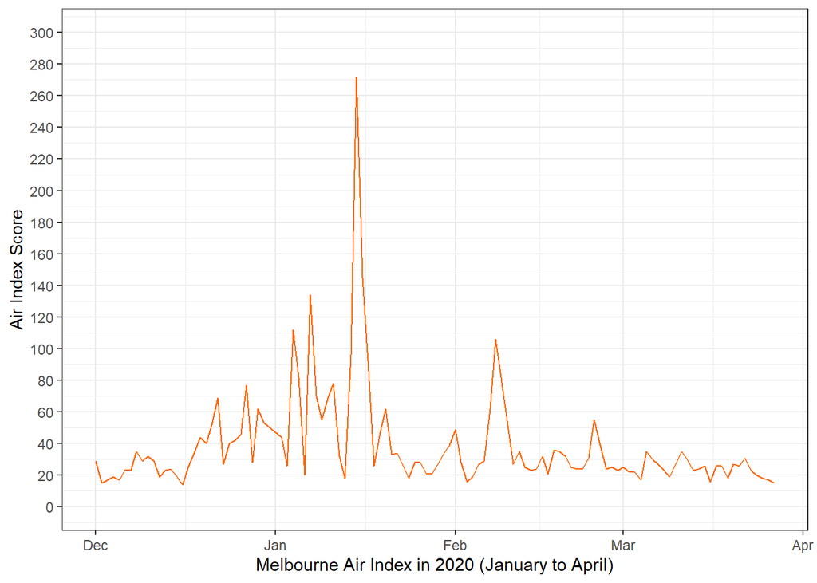

Figure 6: Bushfire Season 2019/2020 Air Quality in Melbourne

```r
melb_air2 %>%
  filter(date >= "2019-12-01" & date <= "2020-03-30" ) %>%


 ggplot()+
  geom_line(aes(x = date,
                y = pm25),
            colour = "#FF6600")+
  theme_bw()+
  labs(x = "Melbourne Air Index in 2020 (January to April)",
       y = "Air Index Score")+
  scale_y_continuous(limits = c(0,300),
                     breaks = seq(0,300,20))
```